# Causal analyses

2022-06-06

In these analyses, we test causal relationships between self and social relevance and broad- and narrowcast sharing intentions with data from Study 6.

# define functions

```r
# MLM results table function
table_model = function(model_data, eff_size = TRUE) {

  results = model_data %>%
    broom.mixed::tidy(conf.int = TRUE) %>%
    filter(effect == "fixed") %>%
    rename("SE" = std.error,
           "t" = statistic,
           "p" = p.value) %>%
    select(-group, -effect) %>%
    mutate_at(vars(-contains("term"), -contains("p.value")), round, 2) %>%
    mutate(term = gsub("article_cond", "", term),
           term = gsub("\\(Intercept\\)", "control", term),
           term = gsub("sharing_type", "sharing type", term),
           term = gsub("msg_rel_self_between", "self-relevance", term),
           term = gsub("msg_rel_social_between", "social relevance", term),
           term = gsub("contentclimate", "content (climate)", term),
           term = gsub("n_c", "word count", term),
           term = gsub(":", " x ", term),
           p = ifelse(p < .001, "< .001",
                      ifelse(p == 1, "1.000", gsub("0.(.*)", ".\\1", sprintf("%.3f", p)))),
           `b [95% CI]` = sprintf("%.2f [%0.2f, %.2f]", estimate, conf.low, conf.high))

  if (eff_size == TRUE) {
    eff_size = lme.dscore(model_data, data = study6, type = "lme4") %>%
      rownames_to_column(var = "term") %>%
      mutate(term = gsub("article_cond", "", term),
             term = gsub("article_cond", "", term),
             term = gsub("\\(Intercept\\)", "control", term),
             term = gsub("sharing_type", "sharing type", term),
             term = gsub("msg_rel_self_between", "self-relevance", term),
             term = gsub("msg_rel_social_between", "social relevance", term),
             term = gsub("contentclimate", "content (climate)", term),
             term = gsub(":", " x ", term),
             d = sprintf("%.2f", d)) %>%
      select(term, d)

    results %>%
      left_join(., eff_size) %>%
      mutate(d = ifelse(is.na(d), "--", d)) %>%
      select(term, `b [95% CI]`, d, df, t, p) %>%
      kable() %>%
      kableExtra::kable_styling()

  } else {
    results %>%
      select(term, `b [95% CI]`, df, t, p) %>%
      kable() %>%
      kableExtra::kable_styling()
  }
}

# Run bayesian mediation model
run_brm_model = function(model_name, model_formula, y_var, data) {
  if (file.exists(sprintf("models/model_%s.RDS", model_name))) {
    assign(get("model_name"), readRDS(sprintf("models/model_%s.RDS", model_name)))
  } else {

    assign(get("model_name"),
           brm(
             model_formula,
             data = data,
             cores = 4,
             thin = 4,
             seed = seed,
             control = list(adapt_delta = .99, max_treedepth = 15)
        ))

    saveRDS(eval(parse(text = model_name)), sprintf("models/model_%s.RDS", model_name))
    return(eval(parse(text = model_name)))
  }
}

# Get path estimates from bayesian mediation models
create_paths = function(model, x_var, y_var) {
  paths = posterior_samples(model) %>%
    mutate(a1 = get(sprintf("b_msgrelself_article_cond%s", x_var)),
           a2 = get(sprintf("b_msgrelsocial_article_cond%s", x_var)),
           b1 = get(sprintf("b_%s_msg_rel_self", y_var)),
           b2 = get(sprintf("b_%s_msg_rel_social", y_var)),
           c_prime = get(sprintf("b_%s_article_cond%s", y_var, x_var)),
           a1b1 = a1 * b1,
           a2b2 = a2 * b2,
           c = c_prime + a1b1 + a2b2,
           cor1 = get(sprintf("cor_SID__msgrelself_article_cond%s__%s_msg_rel_self", x_var, y_var)),
           cor2 = get(sprintf("cor_SID__msgrelsocial_article_cond%s__%s_msg_rel_social", x_var, y_var)),
           sd_a1 = get(sprintf("sd_SID__msgrelself_article_cond%s", x_var)),
           sd_b1 = get(sprintf("sd_SID__%s_msg_rel_self", y_var)),
           sd_a2 = get(sprintf("sd_SID__msgrelsocial_article_cond%s", x_var)),
           sd_b2 = get(sprintf("sd_SID__%s_msg_rel_social", y_var)),
           cov_a1b1 = cor1*sd_a1*sd_b1,
           cov_a2b2 = cor2*sd_a2*sd_b2,
           a1b1_cov_a1b1 = a1b1 + cov_a1b1,
           a2b2_cov_a2b2 = a2b2 + cov_a2b2,
           model = x_var,
           outcome = y_var)

  return(paths)
}

create_paths_words = function(model, x_var, y_var) {
  y_var = gsub("_", "", y_var)
  paths = posterior_samples(model) %>%
    mutate(a1 = get(sprintf("b_nc_article_cond%s", x_var)),
           b1 = get(sprintf("b_%s_n_c", y_var)),
           c_prime = get(sprintf("b_%s_article_cond%s", y_var, x_var)),
           a1b1 = a1 * b1,
           c = c_prime + a1b1,
           cor1 = get(sprintf("cor_SID__nc_article_cond%s__%s_n_c", x_var, y_var)),
           sd_a1 = get(sprintf("sd_SID__nc_article_cond%s", x_var)),
           sd_b1 = get(sprintf("sd_SID__%s_n_c", y_var)),
           cov_a1b1 = cor1*sd_a1*sd_b1,
           a1b1_cov_a1b1 = a1b1 + cov_a1b1,
           model = x_var,
           outcome = y_var)

  return(paths)
}

get_paths = function(model, x_var, y_var) {
  create_paths(model, x_var, y_var) %>%
    select(a1:a2b2_cov_a2b2, -contains("sd"), -contains("cor"), -starts_with("cov")) %>%
    gather(path, value) %>%
    group_by(path) %>%
    summarize(median = median(value),
              `Mdn [95% CI]` = sprintf("%.2f [%.2f, %.2f]", median(value), quantile(value, probs = .025), quantile(value, probs = .975))) %>%
    mutate(path = factor(path, levels = c("a1", "b1", "a1b1", "a1b1_cov_a1b1", "a2", "b2", "a2b2", "a2b2_cov_a2b2", "c", "c_prime"))) %>%
    arrange(path) %>%
    select(-median) %>%
    kable() %>%
    kableExtra::kable_styling()
}

get_paths_words = function(model, x_var, y_var) {
  create_paths_words(model, x_var, y_var) %>%
    select(a1:a1b1_cov_a1b1, -contains("sd"), -contains("cor"), -starts_with("cov")) %>%
    gather(path, value) %>%
    group_by(path) %>%
    summarize(median = median(value),
              `Mdn [95% CI]` = sprintf("%.2f [%.2f, %.2f]", median(value), quantile(value, probs = .025), quantile(value, probs = .975))) %>%
    mutate(path = factor(path, levels = c("a1", "b1", "a1b1", "a1b1_cov_a1b1", "c", "c_prime"))) %>%
    arrange(path) %>%
    select(-median) %>%
    kable() %>%
    kableExtra::kable_styling()
}

percent_mediated = function(model, x_var, y_var) {
  create_paths(model, x_var, y_var) %>%
    select(a1b1_cov_a1b1, a2b2_cov_a2b2, c) %>%
    gather(path, value) %>%
    group_by(path) %>%
    summarize(median = median(value)) %>%
    select(path, median) %>%
    spread(path, median) %>%
    mutate(self = round((a1b1_cov_a1b1 / c) * 100, 0),
           social = round((a2b2_cov_a2b2 / c) * 100, 0),
           total = self + social) %>%
    select(self, social, total) %>%
    kable(caption = "percent mediated") %>%
    kableExtra::kable_styling()
}

percent_mediated_words = function(model, x_var, y_var) {
  create_paths_words(model, x_var, y_var) %>%
    select(a1b1_cov_a1b1, c) %>%
    gather(path, value) %>%
    group_by(path) %>%
    summarize(median = median(value)) %>%
    select(path, median) %>%
    spread(path, median) %>%
    mutate(word_count = round((a1b1_cov_a1b1 / c) * 100, 0)) %>%
    select(word_count) %>%
    kable(caption = "percent mediated") %>%
    kableExtra::kable_styling()
}
```

# prep data

First, we load the relevant packages and data, and define the plotting aesthetics.

## load packages

```r
if(!require('pacman')) {
    install.packages('pacman')
}

pacman::p_load(tidyverse, knitr, kableExtra, lmerTest, boot, report, brms, tidybayes, ggpubr, tidyText, EMAtools, broom.mixed)
report::cite_packages()
```

```
##   - Alboukadel Kassambara (2020). ggpubr: 'ggplot2' Based Publication Ready Plots. R package version 0.4.0. https://CRAN.R-project.org/package=ggpubr
##   - Angelo Canty and Brian Ripley (2021). boot: Bootstrap R (S-Plus) Functions. R package version 1.3-28.
##   - Ben Bolker and David Robinson (2022). broom.mixed: Tidying Methods for Mixed Models. R package version 0.2.9.3. https://CRAN.R-project.org/package=broom.mixed
##   - Dirk Eddelbuettel and Romain Francois (2011). Rcpp: Seamless R and C++ Integration. Journal of Statistical Software, 40(8), 1-18, <doi:10.18637/jss.v040.i08>.
##   - Douglas Bates and Martin Maechler (2021). Matrix: Sparse and Dense Matrix Classes and Methods. R package version 1.3-4. https://CRAN.R-project.org/package=Matrix
##   - Douglas Bates, Martin Maechler, Ben Bolker, Steve Walker (2015). Fitting Linear Mixed-Effects Models Using lme4. Journal of Statistical Software, 67(1), 1-48. doi:10.18637/jss.v067.i01.
##   - Evan Kleiman (2021). EMAtools: Data Management Tools for Real-Time Monitoring/Ecological Momentary Assessment Data. R package version 0.1.4. https://CRAN.R-project.org/package=EMAtools
##   - H. Wickham. ggplot2: Elegant Graphics for Data Analysis. Springer-Verlag New York, 2016.
##   - Hadley Wickham (2019). stringr: Simple, Consistent Wrappers for Common String Operations. R package version 1.4.0. https://CRAN.R-project.org/package=stringr
##   - Hadley Wickham (2021). forcats: Tools for Working with Categorical Variables (Factors). R package version 0.5.1. https://CRAN.R-project.org/package=forcats
##   - Hadley Wickham and Maximilian Girlich (2022). tidyr: Tidy Messy Data. R package version 1.2.0. https://CRAN.R-project.org/package=tidyr
##   - Hadley Wickham, Jim Hester and Jennifer Bryan (2022). readr: Read Rectangular Text Data. R package version 2.1.2. https://CRAN.R-project.org/package=readr
##   - Hadley Wickham, Romain François, Lionel Henry and Kirill Müller (2022). dplyr: A Grammar of Data Manipulation. R package version 1.0.8. https://CRAN.R-project.org/package=dplyr
##   - Hao Zhu (2021). kableExtra: Construct Complex Table with 'kable' and Pipe Syntax. R package version 1.3.4. https://CRAN.R-project.org/package=kableExtra
##   - Kay M (2022). _tidybayes: Tidy Data and Geoms for Bayesian Models_.doi: 10.5281/zenodo.1308151 (URL:https://doi.org/10.5281/zenodo.1308151), R package version 3.0.2, <URL:http://mjskay.github.io/tidybayes/>.
##   - Kirill Müller and Hadley Wickham (2021). tibble: Simple Data Frames. R package version 3.1.6. https://CRAN.R-project.org/package=tibble
##   - Kuznetsova A, Brockhoff PB, Christensen RHB (2017). "lmerTest Package:Tests in Linear Mixed Effects Models." _Journal of StatisticalSoftware_, *82*(13), 1-26. doi: 10.18637/jss.v082.i13 (URL:https://doi.org/10.18637/jss.v082.i13).
##   - Lionel Henry and Hadley Wickham (2020). purrr: Functional Programming Tools. R package version 0.3.4. https://CRAN.R-project.org/package=purrr
##   - Makowski, D., Ben-Shachar, M.S., Patil, I. & Lüdecke, D. (2020). Automated Results Reporting as a Practical Tool to Improve Reproducibility and Methodological Best Practices Adoption. CRAN. Available from https://github.com/easystats/report. doi: .
##   - Paul-Christian Bürkner (2017). brms: An R Package for Bayesian Multilevel Models Using Stan. Journal of Statistical Software, 80(1), 1-28. doi:10.18637/jss.v080.i01
##   - R Core Team (2021). R: A language and environment for statistical computing. R Foundation for Statistical Computing, Vienna, Austria. URL https://www.R-project.org/.
##   - Rinker, T. W. & Kurkiewicz, D. (2017). pacman: Package Management for R. version 0.5.0. Buffalo, New York. http://github.com/trinker/pacman
##   - Wickham et al., (2019). Welcome to the tidyverse. Journal of Open Source Software, 4(43), 1686, https://doi.org/10.21105/joss.01686
##   - Yihui Xie (2021). knitr: A General-Purpose Package for Dynamic Report Generation in R. R package version 1.37.
```

## define aesthetics

```r
palette_condition = c("#ee9b00", "#bb3e03", "#005f73")
palette_sharing = c("#086E70", "#FFA600")
palette_content = c("#9FC490", "#43BCCD")
palette_relevance = c("#FB590E", "#00667A")

plot_aes = theme_minimal() +
  theme(legend.position = "top",
        legend.text = element_text(size = 12),
        text = element_text(size = 16, family = "Futura Medium"),
        axis.text = element_text(color = "black"),
        axis.line = element_line(colour = "black"),
        axis.ticks.y = element_blank())
```

## load data

```r
study6 = read.csv("../data/study6.csv", stringsAsFactors = FALSE) %>%
  mutate(content = factor(content, levels = c("health", "climate")))

study6_comments = read.csv("../data/study6_comments.csv", stringsAsFactors = FALSE)
```

# condition ns

```r
study6 %>%
  select(group, SID) %>%
  unique() %>%
  group_by(group) %>%
  summarize(n = n())
```

| group | n |
| --- | --- |
| self | 200 |
| social | 197 |

# manipulation checks

## self-relevance

Test whether messages in the self condition will be rated as more self-relevant than messages in the control condition.

### run model

```r
mod_h1 = lmer(msg_rel_self ~ 1 + article_cond + (1 + article_cond | SID),
              data = study6,
              control = lmerControl(optimizer = "bobyqa"))
summary(mod_h1)
```

```
## Linear mixed model fit by REML. t-tests use Satterthwaite's method [
## lmerModLmerTest]
## Formula: msg_rel_self ~ 1 + article_cond + (1 + article_cond | SID)
##    Data: study6
## Control: lmerControl(optimizer = "bobyqa")
##
## REML criterion at convergence: 74144.5
##
## Scaled residuals:
##     Min      1Q  Median      3Q     Max
## -3.3486 -0.5966  0.0850  0.5823  3.3875
##
## Random effects:
##  Groups   Name               Variance Std.Dev. Corr
##  SID      (Intercept)        489.1    22.12
##           article_condself   222.4    14.91    -0.44
##           article_condsocial 145.9    12.08    -0.34  0.06
##  Residual                    552.3    23.50
## Number of obs: 7940, groups:  SID, 397
##
## Fixed effects:
##                    Estimate Std. Error      df t value             Pr(>|t|)
## (Intercept)          52.849      1.171 396.000  45.132 < 0.0000000000000002 ***
## article_condself     12.408      1.218 225.445  10.189 < 0.0000000000000002 ***
## article_condsocial    5.118      1.096 212.745   4.671           0.00000532 ***
## ---
## Signif. codes:  0 '***' 0.001 '**' 0.01 '*' 0.05 '.' 0.1 ' ' 1
##
## Correlation of Fixed Effects:
##             (Intr) artcl_cndsl
## artcl_cndsl -0.352
## artcl_cndsc -0.287  0.101
```

### model summary table

```r
table_model(mod_h1)
```

| term | b [95% CI] | d | df | t | p |
| --- | --- | --- | --- | --- | --- |
| control | 52.85 [50.55, 55.15] | – | 396.00 | 45.13 | < .001 |
| self | 12.41 [10.01, 14.81] | 1.36 | 225.44 | 10.19 | < .001 |
| social | 5.12 [2.96, 7.28] | 0.64 | 212.74 | 4.67 | < .001 |

## social relevance

Test whether messages in the social condition will be rated as more socially relevant than messages in the control condition.

### run model

```r
mod_h2 = lmer(msg_rel_social ~ 1 + article_cond + (1 + article_cond | SID),
              data = study6,
              control = lmerControl(optimizer = "bobyqa"))
summary(mod_h2)
```

```
## Linear mixed model fit by REML. t-tests use Satterthwaite's method [
## lmerModLmerTest]
## Formula: msg_rel_social ~ 1 + article_cond + (1 + article_cond | SID)
##    Data: study6
## Control: lmerControl(optimizer = "bobyqa")
##
## REML criterion at convergence: 72201.7
##
## Scaled residuals:
##     Min      1Q  Median      3Q     Max
## -3.8896 -0.4633  0.0913  0.5490  3.4932
##
## Random effects:
##  Groups   Name               Variance Std.Dev. Corr
##  SID      (Intercept)        481.0    21.93
##           article_condself   158.1    12.57    -0.46
##           article_condsocial 167.1    12.93    -0.47  0.27
##  Residual                    426.8    20.66
## Number of obs: 7940, groups:  SID, 397
##
## Fixed effects:
##                    Estimate Std. Error      df t value             Pr(>|t|)
## (Intercept)          58.436      1.149 396.000   50.88 < 0.0000000000000002 ***
## article_condself      8.656      1.040 228.124    8.32  0.00000000000000804 ***
## article_condsocial    8.904      1.062 220.989    8.38  0.00000000000000616 ***
## ---
## Signif. codes:  0 '***' 0.001 '**' 0.01 '*' 0.05 '.' 0.1 ' ' 1
##
## Correlation of Fixed Effects:
##             (Intr) artcl_cndsl
## artcl_cndsl -0.356
## artcl_cndsc -0.365  0.130
```

### model summary table

```r
table_model(mod_h2)
```

| term | b [95% CI] | d | df | t | p |
| --- | --- | --- | --- | --- | --- |
| control | 58.44 [56.18, 60.69] | – | 396.00 | 50.88 | < .001 |
| self | 8.66 [6.61, 10.71] | 1.10 | 228.12 | 8.32 | < .001 |
| social | 8.90 [6.81, 11.00] | 1.13 | 220.99 | 8.38 | < .001 |

# condition effects by sharing type

Test whether messages in the experimental conditions will evoke higher sharing intentions than messages in the control condition, and whether this is moderated by sharing type.

## run model

```r
mod_h3_h4 = lmer(msg_share ~ 1 + article_cond*sharing_type + (1 + sharing_type | SID),
              data = study6,
              control = lmerControl(optimizer = "bobyqa"))
summary(mod_h3_h4)
```

```
## Linear mixed model fit by REML. t-tests use Satterthwaite's method [
## lmerModLmerTest]
## Formula: msg_share ~ 1 + article_cond * sharing_type + (1 + sharing_type |
##     SID)
##    Data: study6
## Control: lmerControl(optimizer = "bobyqa")
##
## REML criterion at convergence: 71638.9
##
## Scaled residuals:
##     Min      1Q  Median      3Q     Max
## -4.0176 -0.4887 -0.0143  0.4899  4.3824
##
## Random effects:
##  Groups   Name         Variance Std.Dev. Corr
##  SID      (Intercept)  845.7    29.08
##           sharing_type 128.1    11.32    -0.44
##  Residual              386.8    19.67
## Number of obs: 7939, groups:  SID, 397
##
## Fixed effects:
##                                  Estimate Std. Error        df t value
## (Intercept)                       45.0383     1.5249  431.3357  29.536
## article_condself                   5.2305     0.8489 7536.0749   6.162
## article_condsocial                 3.3742     0.8546 7535.2126   3.948
## sharing_type                       0.1607     0.8440  743.4852   0.190
## article_condself:sharing_type      2.0847     1.1538 6961.8849   1.807
## article_condsocial:sharing_type    3.5251     1.1609 6926.6611   3.036
##                                             Pr(>|t|)
## (Intercept)                     < 0.0000000000000002 ***
## article_condself                      0.000000000756 ***
## article_condsocial                    0.000079372297 ***
## sharing_type                                  0.8490
## article_condself:sharing_type                 0.0708 .
## article_condsocial:sharing_type               0.0024 **
## ---
## Signif. codes:  0 '***' 0.001 '**' 0.01 '*' 0.05 '.' 0.1 ' ' 1
##
## Correlation of Fixed Effects:
##               (Intr) artcl_cndsl artcl_cndsc shrng_ artcl_cndsl:_
## artcl_cndsl   -0.151
## artcl_cndsc   -0.150  0.075
## sharing_typ   -0.433  0.272       0.270
## artcl_cndsl:_  0.111 -0.686      -0.106      -0.400
## artcl_cndsc:_  0.110 -0.106      -0.685      -0.398  0.164
```

## model summary table

```r
table_model(mod_h3_h4)
```

| term | b [95% CI] | d | df | t | p |
| --- | --- | --- | --- | --- | --- |
| control | 45.04 [42.04, 48.04] | – | 431.34 | 29.54 | < .001 |
| self | 5.23 [3.57, 6.89] | 0.14 | 7536.07 | 6.16 | < .001 |
| social | 3.37 [1.70, 5.05] | 0.09 | 7535.21 | 3.95 | < .001 |
| sharing type | 0.16 [-1.50, 1.82] | 0.01 | 743.49 | 0.19 | .850 |
| self x sharing type | 2.08 [-0.18, 4.35] | 0.04 | 6961.88 | 1.81 | .070 |
| social x sharing type | 3.53 [1.25, 5.80] | 0.07 | 6926.66 | 3.04 | < .001 |

# combined plot

This is the plot in Figure 4.

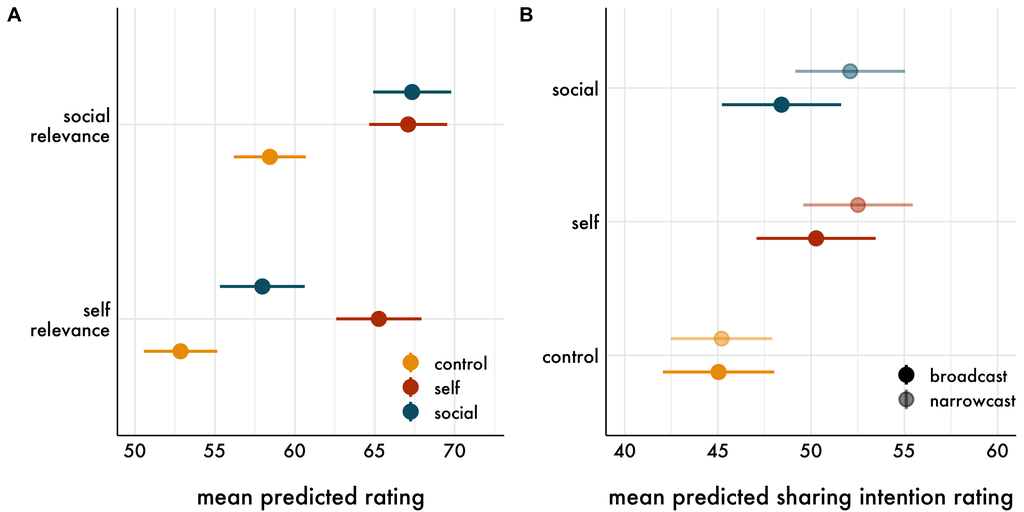

```r
# generate predicted values
predicted_h1 = ggeffects::ggpredict(mod_h1, c("article_cond")) %>%
              data.frame() %>%
  mutate(model = "self\nrelevance")

predicted_h2 = ggeffects::ggpredict(mod_h2, c("article_cond")) %>%
              data.frame() %>%
  mutate(model = "social\nrelevance")

predicted_h3_h4 = ggeffects::ggpredict(mod_h3_h4, c("article_cond", "sharing_type")) %>%
              data.frame() %>%
  mutate(group = ifelse(group == "0", "broadcast sharing", "narrowcast sharing"))

# manipulation check plot
check = bind_rows(predicted_h1, predicted_h2) %>%
  ggplot(aes(x = model, y = predicted, color = x)) +
    geom_pointrange(aes( ymin = conf.low, ymax = conf.high), position = position_dodge(.5), size = 1) +
    coord_flip() +
    scale_color_manual(name = "", values = palette_condition) +
    scale_y_continuous(limits = c(50, 72)) +
    labs(x = "", y = "\nmean predicted rating") +
    plot_aes +
    theme(legend.position = c(.85, .15))

# causal analysis plot
causal = predicted_h3_h4 %>%
  mutate(group = gsub(" sharing", "", group)) %>%
  ggplot(aes(x = x, y = predicted, color = x)) +
  geom_pointrange(aes(ymin = conf.low, ymax = conf.high, alpha = group), position = position_dodge(.5), size = 1) +
  coord_flip() +
  scale_color_manual(name = "", values = palette_condition, guide = "none") +
  scale_alpha_manual(name = "", values = c(1, .5)) +
  labs(x = "", y = "\nmean predicted sharing intention rating") +
  scale_y_continuous(limits = c(40, 60)) +
  plot_aes +
  theme(legend.position = c(.85, .15))

cowplot::plot_grid(check, causal, labels = c("A", "B"))
```

# mediation

Use [Elizabeth Page-Gould’s code for estimating indirect effects in multilevel models](http://www.page-gould.com/r/indirectmlm/) to test whether the experimental effects on sharing intentions are mediate through self or social relevance.

## prep data

```r
# source functions
source("indirectMLM.R")

# create self condition dataframe
data_med_self = study6 %>%
  filter(group == "self") %>%
  mutate(article_cond = ifelse(article_cond == "self", 1, 0),
         sharing_type = ifelse(sharing_type == 0, "broadcast", "narrowcast"),
         SID = as.character(SID)) %>%
  spread(sharing_type, msg_share) %>%
  select(SID, article_cond, trial, msg_rel_self, broadcast, narrowcast) %>%
  na.omit() %>%
  data.frame()

# create social condition dataframe
data_med_social = study6 %>%
  filter(group == "social") %>%
  mutate(article_cond = ifelse(article_cond == "social", 1, 0),
         sharing_type = ifelse(sharing_type == 0, "broadcast", "narrowcast"),
         SID = as.character(SID)) %>%
  spread(sharing_type, msg_share) %>%
  select(SID, article_cond, trial, msg_rel_social, broadcast, narrowcast) %>%
  na.omit() %>%
  data.frame()
```

## self condition

Test whether there is an indirect effect through self-relevance, such that the self-relevance manipulation will be associated with higher self-relevance ratings, which in turn will be related to stronger a) broadcast and b) narrowcast sharing intentions.

### broadcast intentions

```r
y_var = "broadcast"
m_var = "msg_rel_self"
model_name = "mediation_self_broadcast"
data = data_med_self

if (file.exists(sprintf("models/model_%s.RDS", model_name))) {
  assign(get("model_name"), readRDS(sprintf("models/model_%s.RDS", model_name)))
} else {
  assign(get("model_name"), boot(data = data, statistic = indirect.mlm, R = 500,
                                 y = y_var, x = "article_cond", mediator = m_var, group.id = "SID",
                                 between.m = F, uncentered.x = F))
  saveRDS(eval(parse(text = model_name)), sprintf("models/model_%s.RDS", model_name))
}

indirect.mlm.summary(get(model_name))
```

```
## #### Population Covariance ####
## Covariance of Random Slopes a and b: -0.129 [-0.516, 0.294]
##
##
## #### Indirect Effects ####
## # Within-subject Effects
## Unbiased Estimate of Within-subjects Indirect Effect: 4.21 [3.362, 5.073]
## Biased Estimate of Within-subjects Indirect Effect: 4.339 [3.5, 5.151]
## Bias in Within-subjects Indirect Effect: 0.128 [0.006, 0.52]
##
##
## #### Total Effect ####
## Unbiased Estimate of Total Effect: 5.377 [3.828, 6.86]
## Biased Total Effect of X on Y (c path): 5.48 [3.851, 7.032]
## Bias in Total Effect: 0.103 [0.008, 0.448]
##
##
## #### Direct Effects ####
## Direct Effect of Predictor on Dependent Variable (c' path): 1.167 [-0.127, 2.668]
## Within-subjects Effect of Predictor on Mediator (a path for group-mean centered predictor): 12.629 [10.572, 14.777]
## Within-subjects Effect of Mediator on Dependent Variable (b path for group-mean centered mediator): 0.344 [0.308, 0.378]
```

```r
# percent mediated
sprintf("percent mediated = %s", round(((12.629 * 0.344) / 5.377) * 100, 0))
```

```
## [1] "percent mediated = 81"
```

### narrowcast intentions

```r
y_var = "narrowcast"
m_var = "msg_rel_self"
model_name = "mediation_self_narrowcast"
data = data_med_self

if (file.exists(sprintf("models/model_%s.RDS", model_name))) {
  assign(get("model_name"), readRDS(sprintf("models/model_%s.RDS", model_name)))
} else {
  assign(get("model_name"), boot(data = data, statistic = indirect.mlm, R = 500,
                                 y = y_var, x = "article_cond", mediator = m_var, group.id = "SID",
                                 between.m = F, uncentered.x = F))
  saveRDS(eval(parse(text = model_name)), sprintf("models/model_%s.RDS", model_name))
}

indirect.mlm.summary(get(model_name))
```

```
## #### Population Covariance ####
## Covariance of Random Slopes a and b: -0.039 [-0.428, 0.595]
##
##
## #### Indirect Effects ####
## # Within-subject Effects
## Unbiased Estimate of Within-subjects Indirect Effect: 5.294 [4.288, 6.45]
## Biased Estimate of Within-subjects Indirect Effect: 5.332 [4.228, 6.213]
## Bias in Within-subjects Indirect Effect: 0.038 [0.011, 0.612]
##
##
## #### Total Effect ####
## Unbiased Estimate of Total Effect: 6.789 [5.291, 8.528]
## Biased Total Effect of X on Y (c path): 7.063 [5.324, 8.728]
## Bias in Total Effect: 0.274 [0.011, 0.527]
##
##
## #### Direct Effects ####
## Direct Effect of Predictor on Dependent Variable (c' path): 1.495 [0.028, 3.025]
## Within-subjects Effect of Predictor on Mediator (a path for group-mean centered predictor): 12.629 [10.519, 14.523]
## Within-subjects Effect of Mediator on Dependent Variable (b path for group-mean centered mediator): 0.422 [0.377, 0.453]
```

```r
# percent mediated
sprintf("percent mediated = %s", round(((12.629 * 0.422) / 6.789) * 100, 0))
```

```
## [1] "percent mediated = 79"
```

## social condition

Test whether there is an indirect effect through social relevance, such that the social relevance manipulation will be associated with higher social relevance ratings, which in turn will be related to stronger a) broadcast and b) narrowcast sharing intentions.

### broadcast intentions

```r
y_var = "broadcast"
m_var = "msg_rel_social"
model_name = "mediation_social_broadcast"
data = data_med_social

if (file.exists(sprintf("models/model_%s.RDS", model_name))) {
  assign(get("model_name"), readRDS(sprintf("models/model_%s.RDS", model_name)))
} else {
  assign(get("model_name"), boot(data = data, statistic = indirect.mlm, R = 500,
                                 y = y_var, x = "article_cond", mediator = m_var, group.id = "SID",
                                 between.m = F, uncentered.x = F))
  saveRDS(eval(parse(text = model_name)), sprintf("models/model_%s.RDS", model_name))
}

indirect.mlm.summary(get(model_name))
```

```
## #### Population Covariance ####
## Covariance of Random Slopes a and b: -0.302 [-0.824, 0.074]
##
##
## #### Indirect Effects ####
## # Within-subject Effects
## Unbiased Estimate of Within-subjects Indirect Effect: 3.759 [2.691, 4.711]
## Biased Estimate of Within-subjects Indirect Effect: 4.059 [3.037, 5.098]
## Bias in Within-subjects Indirect Effect: 0.301 [0.012, 0.82]
##
##
## #### Total Effect ####
## Unbiased Estimate of Total Effect: 3.402 [1.719, 4.812]
## Biased Total Effect of X on Y (c path): 3.122 [1.524, 4.79]
## Bias in Total Effect: 0.28 [0.009, 0.409]
##
##
## #### Direct Effects ####
## Direct Effect of Predictor on Dependent Variable (c' path): -0.357 [-1.81, 1.007]
## Within-subjects Effect of Predictor on Mediator (a path for group-mean centered predictor): 8.591 [6.71, 10.646]
## Within-subjects Effect of Mediator on Dependent Variable (b path for group-mean centered mediator): 0.472 [0.431, 0.509]
```

```r
# percent mediated
sprintf("percent mediated = %s", round(((8.591 * 0.472) / 3.402) * 100, 0))
```

```
## [1] "percent mediated = 119"
```

### narrowcast intentions

```r
y_var = "narrowcast"
m_var = "msg_rel_social"
model_name = "mediation_social_narrowcast"
data = data_med_social

if (file.exists(sprintf("models/model_%s.RDS", model_name))) {
  assign(get("model_name"), readRDS(sprintf("models/model_%s.RDS", model_name)))
} else {
  assign(get("model_name"), boot(data = data, statistic = indirect.mlm, R = 500,
                                 y = y_var, x = "article_cond", mediator = m_var, group.id = "SID",
                                 between.m = F, uncentered.x = F))
  saveRDS(eval(parse(text = model_name)), sprintf("models/model_%s.RDS", model_name))
}

indirect.mlm.summary(get(model_name))
```

```
## #### Population Covariance ####
## Covariance of Random Slopes a and b: -0.247 [-0.655, 0.177]
##
##
## #### Indirect Effects ####
## # Within-subject Effects
## Unbiased Estimate of Within-subjects Indirect Effect: 4.482 [3.4, 5.491]
## Biased Estimate of Within-subjects Indirect Effect: 4.728 [3.644, 5.711]
## Bias in Within-subjects Indirect Effect: 0.246 [0.011, 0.652]
##
##
## #### Total Effect ####
## Unbiased Estimate of Total Effect: 7.326 [5.325, 8.797]
## Biased Total Effect of X on Y (c path): 7.162 [5.305, 8.829]
## Bias in Total Effect: 0.163 [0.005, 0.385]
##
##
## #### Direct Effects ####
## Direct Effect of Predictor on Dependent Variable (c' path): 2.843 [1.231, 4.147]
## Within-subjects Effect of Predictor on Mediator (a path for group-mean centered predictor): 8.591 [6.75, 10.425]
## Within-subjects Effect of Mediator on Dependent Variable (b path for group-mean centered mediator): 0.55 [0.5, 0.589]
```

```r
# percent mediated
sprintf("percent mediated = %s", round(((8.591 * 0.55) / 7.326) * 100, 0))
```

```
## [1] "percent mediated = 64"
```

# post-hoc

These analyses were added in response to feedback from reviewers during peer review.

## moderation by article content

Are the relationships moderated by article content types (health or climate)?

### self-relevance

#### run model

Note: The model allowing both condition and article content type to vary randomly across people did not converge. We therefore used AIC to select the best fitting random effects structure and summarize results from this model

```r
mod_h1_1 = lmer(msg_rel_self ~ 1 + article_cond * content + (1 + article_cond | SID),
              data = study6,
              control = lmerControl(optimizer = "bobyqa"))
mod_h1_2 = lmer(msg_rel_self ~ 1 + article_cond * content + (1 + content | SID),
              data = study6,
              control = lmerControl(optimizer = "bobyqa"))
anova(mod_h1_1, mod_h1_2)
```

|  | npar | AIC | BIC | logLik | deviance | Chisq | Df | Pr(>Chisq) |
| --- | --- | --- | --- | --- | --- | --- | --- | --- |
| mod_h1_2 | 10 | 73594.48 | 73664.27 | -36787.24 | 73574.48 | NA | NA | NA |
| mod_h1_1 | 13 | 74143.79 | 74234.52 | -37058.89 | 74117.79 | 0 | 3 | 1 |

```r
summary(mod_h1_2)
```

```
## Linear mixed model fit by REML. t-tests use Satterthwaite's method [
## lmerModLmerTest]
## Formula: msg_rel_self ~ 1 + article_cond * content + (1 + content | SID)
##    Data: study6
## Control: lmerControl(optimizer = "bobyqa")
##
## REML criterion at convergence: 73563
##
## Scaled residuals:
##     Min      1Q  Median      3Q     Max
## -3.4975 -0.5745  0.0706  0.5683  3.6967
##
## Random effects:
##  Groups   Name           Variance Std.Dev. Corr
##  SID      (Intercept)    489.4    22.12
##           contentclimate 393.1    19.83    -0.38
##  Residual                495.1    22.25
## Number of obs: 7940, groups:  SID, 397
##
## Fixed effects:
##                                    Estimate Std. Error        df t value
## (Intercept)                         51.1853     1.2211  476.5708  41.918
## article_condself                    13.2763     1.0107 7500.6358  13.136
## article_condsocial                   5.3246     1.0138 7488.0287   5.252
## contentclimate                       3.4472     1.2309  589.1541   2.801
## article_condself:contentclimate     -2.2894     1.4120 7490.1761  -1.621
## article_condsocial:contentclimate   -0.1779     1.4179 7477.5483  -0.125
##                                               Pr(>|t|)
## (Intercept)                       < 0.0000000000000002 ***
## article_condself                  < 0.0000000000000002 ***
## article_condsocial                         0.000000154 ***
## contentclimate                                 0.00527 **
## article_condself:contentclimate                0.10499
## article_condsocial:contentclimate              0.90016
## ---
## Signif. codes:  0 '***' 0.001 '**' 0.01 '*' 0.05 '.' 0.1 ' ' 1
##
## Correlation of Fixed Effects:
##              (Intr) artcl_cndsl artcl_cndsc cntntc artcl_cndsl:
## artcl_cndsl  -0.217
## artcl_cndsc  -0.220  0.066
## contentclmt  -0.454  0.217       0.220
## artcl_cndsl:  0.157 -0.698      -0.072      -0.318
## artcl_cndsc:  0.158 -0.071      -0.697      -0.315  0.100
```

#### model summary table

```r
table_model(mod_h1_2)
```

| term | b [95% CI] | d | df | t | p |
| --- | --- | --- | --- | --- | --- |
| control | 51.19 [48.79, 53.58] | – | 476.57 | 41.92 | < .001 |
| self | 13.28 [11.30, 15.26] | 0.30 | 7500.64 | 13.14 | < .001 |
| social | 5.32 [3.34, 7.31] | 0.12 | 7488.03 | 5.25 | < .001 |
| content (climate) | 3.45 [1.03, 5.86] | 0.23 | 589.15 | 2.80 | .010 |
| self x content (climate) | -2.29 [-5.06, 0.48] | -0.04 | 7490.18 | -1.62 | .100 |
| social x content (climate) | -0.18 [-2.96, 2.60] | -0.00 | 7477.55 | -0.13 | .900 |

### social relevance

#### run model

```r
mod_h2 = lmer(msg_rel_social ~ 1 + article_cond * content + (1 + article_cond + content | SID),
              data = study6,
              control = lmerControl(optimizer = "bobyqa"))
summary(mod_h2)
```

```
## Linear mixed model fit by REML. t-tests use Satterthwaite's method [
## lmerModLmerTest]
## Formula: msg_rel_social ~ 1 + article_cond * content + (1 + article_cond +
##     content | SID)
##    Data: study6
## Control: lmerControl(optimizer = "bobyqa")
##
## REML criterion at convergence: 71331.2
##
## Scaled residuals:
##     Min      1Q  Median      3Q     Max
## -4.2233 -0.4311  0.0831  0.5342  3.7533
##
## Random effects:
##  Groups   Name               Variance Std.Dev. Corr
##  SID      (Intercept)        491.6    22.17
##           article_condself   165.2    12.85    -0.39
##           article_condsocial 203.8    14.28    -0.48 -0.06
##           contentclimate     283.4    16.83    -0.20 -0.12 -0.03
##  Residual                    347.1    18.63
## Number of obs: 7940, groups:  SID, 397
##
## Fixed effects:
##                                   Estimate Std. Error       df t value
## (Intercept)                         61.343      1.194  418.312  51.395
## article_condself                     7.493      1.200  380.443   6.247
## article_condsocial                   7.742      1.253  350.234   6.178
## contentclimate                      -5.723      1.048  582.803  -5.460
## article_condself:contentclimate      1.929      1.184 7130.851   1.629
## article_condsocial:contentclimate    2.233      1.188 7125.900   1.879
##                                               Pr(>|t|)
## (Intercept)                       < 0.0000000000000002 ***
## article_condself                         0.00000000112 ***
## article_condsocial                       0.00000000180 ***
## contentclimate                           0.00000007037 ***
## article_condself:contentclimate                 0.1033
## article_condsocial:contentclimate               0.0603 .
## ---
## Signif. codes:  0 '***' 0.001 '**' 0.01 '*' 0.05 '.' 0.1 ' ' 1
##
## Correlation of Fixed Effects:
##              (Intr) artcl_cndsl artcl_cndsc cntntc artcl_cndsl:
## artcl_cndsl  -0.329
## artcl_cndsc  -0.386  0.127
## contentclmt  -0.300  0.099       0.135
## artcl_cndsl:  0.135 -0.498      -0.058      -0.313
## artcl_cndsc:  0.135 -0.045      -0.461      -0.310  0.099
```

#### model summary table

```r
table_model(mod_h2)
```

| term | b [95% CI] | d | df | t | p |
| --- | --- | --- | --- | --- | --- |
| control | 61.34 [59.00, 63.69] | – | 418.31 | 51.40 | < .001 |
| self | 7.49 [5.13, 9.85] | 0.64 | 380.44 | 6.25 | < .001 |
| social | 7.74 [5.28, 10.21] | 0.66 | 350.23 | 6.18 | < .001 |
| content (climate) | -5.72 [-7.78, -3.66] | -0.45 | 582.80 | -5.46 | < .001 |
| self x content (climate) | 1.93 [-0.39, 4.25] | 0.04 | 7130.85 | 1.63 | .100 |
| social x content (climate) | 2.23 [-0.10, 4.56] | 0.04 | 7125.90 | 1.88 | .060 |

### sharing

#### run model

```r
mod_h3_h4 = lmer(msg_share ~ 1 + article_cond*sharing_type*content + (1 + sharing_type + content | SID),
              data = study6,
              control = lmerControl(optimizer = "bobyqa"))
summary(mod_h3_h4)
```

```
## Linear mixed model fit by REML. t-tests use Satterthwaite's method [
## lmerModLmerTest]
## Formula: msg_share ~ 1 + article_cond * sharing_type * content + (1 +
##     sharing_type + content | SID)
##    Data: study6
## Control: lmerControl(optimizer = "bobyqa")
##
## REML criterion at convergence: 71332.9
##
## Scaled residuals:
##     Min      1Q  Median      3Q     Max
## -3.8661 -0.4764 -0.0139  0.4778  4.2978
##
## Random effects:
##  Groups   Name           Variance Std.Dev. Corr
##  SID      (Intercept)    865.8    29.42
##           sharing_type   135.2    11.63    -0.41
##           contentclimate 124.4    11.15    -0.14 -0.12
##  Residual                351.2    18.74
## Number of obs: 7939, groups:  SID, 397
##
## Fixed effects:
##                                                 Estimate Std. Error        df
## (Intercept)                                      44.3935     1.5942  477.2320
## article_condself                                  4.2828     1.1396 7083.9962
## article_condsocial                                3.9382     1.1405 7067.0243
## sharing_type                                      2.0942     1.0261 1504.9798
## contentclimate                                    1.4479     1.0262 1695.6117
## article_condself:sharing_type                     2.2286     1.5367 7101.1088
## article_condsocial:sharing_type                   3.9765     1.5354 7082.5075
## article_condself:contentclimate                   1.4750     1.5691 7301.8591
## article_condsocial:contentclimate                -1.3762     1.5743 7291.9623
## sharing_type:contentclimate                      -3.9082     1.2100 6964.9808
## article_condself:sharing_type:contentclimate     -0.2526     2.1148 7063.1436
## article_condsocial:sharing_type:contentclimate   -0.7646     2.1222 7053.9721
##                                                t value             Pr(>|t|)
## (Intercept)                                     27.846 < 0.0000000000000002 ***
## article_condself                                 3.758             0.000173 ***
## article_condsocial                               3.453             0.000557 ***
## sharing_type                                     2.041             0.041427 *
```

[output cut: 21 more lines]

```
## shrng_typ:c     0.188 -0.270      -0.272      -0.583 -0.590  0.401
## artcl_cndsl:_: -0.111  0.468       0.161       0.345  0.349 -0.695
## artcl_cndsc:_: -0.110  0.159       0.464       0.343  0.348 -0.236
##                artcl_cndsc:_ artcl_cndsl: artcl_cndsc: shrn_: artcl_cndsl:_:
## artcl_cndsl
## artcl_cndsc
## sharing_typ
## contentclmt
## artcl_cndsl:_
## artcl_cndsc:_
## artcl_cndsl:    0.166
## artcl_cndsc:    0.461         0.250
## shrng_typ:c     0.405         0.400        0.397
## artcl_cndsl:_: -0.239        -0.675       -0.235       -0.591
## artcl_cndsc:_: -0.689        -0.235       -0.675       -0.588  0.348
```

#### model summary table

```r
table_model(mod_h3_h4)
```

| term | b [95% CI] | d | df | t | p |
| --- | --- | --- | --- | --- | --- |
| control | 44.39 [41.26, 47.53] | – | 477.23 | 27.85 | < .001 |
| self | 4.28 [2.05, 6.52] | 0.09 | 7084.00 | 3.76 | < .001 |
| social | 3.94 [1.70, 6.17] | 0.08 | 7067.02 | 3.45 | < .001 |
| sharing type | 2.09 [0.08, 4.11] | 0.11 | 1504.98 | 2.04 | .040 |
| content (climate) | 1.45 [-0.56, 3.46] | 0.07 | 1695.61 | 1.41 | .160 |
| self x sharing type | 2.23 [-0.78, 5.24] | 0.03 | 7101.11 | 1.45 | .150 |
| social x sharing type | 3.98 [0.97, 6.99] | 0.06 | 7082.51 | 2.59 | .010 |
| self x content (climate) | 1.47 [-1.60, 4.55] | 0.02 | 7301.86 | 0.94 | .350 |
| social x content (climate) | -1.38 [-4.46, 1.71] | -0.02 | 7291.96 | -0.87 | .380 |
| sharing type x content (climate) | -3.91 [-6.28, -1.54] | -0.08 | 6964.98 | -3.23 | < .001 |
| self x sharing type x content (climate) | -0.25 [-4.40, 3.89] | -0.00 | 7063.14 | -0.12 | .900 |
| social x sharing type x content (climate) | -0.76 [-4.92, 3.40] | -0.01 | 7053.97 | -0.36 | .720 |

### plot

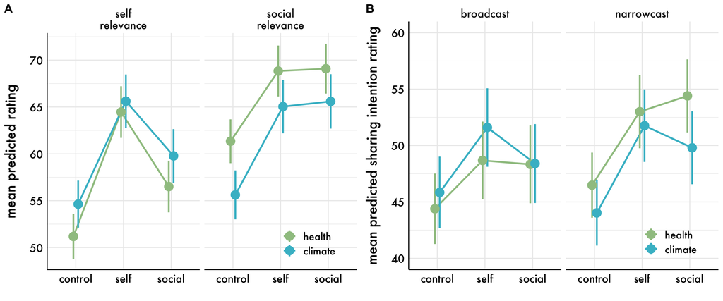

```r
# generate predicted values
predicted_h1 = ggeffects::ggpredict(mod_h1_2, c("article_cond", "content")) %>%
              data.frame() %>%
  mutate(model = "self\nrelevance")

predicted_h2 = ggeffects::ggpredict(mod_h2, c("article_cond", "content")) %>%
              data.frame() %>%
  mutate(model = "social\nrelevance")

predicted_h3_h4 = ggeffects::ggpredict(mod_h3_h4, c("article_cond", "sharing_type", "content")) %>%
              data.frame() %>%
  mutate(group = ifelse(group == "0", "broadcast sharing", "narrowcast sharing"))

# manipulation check plot
check = bind_rows(predicted_h1, predicted_h2) %>%
  ggplot(aes(x = x, y = predicted, color = group)) +
  stat_summary(aes(group = group), fun.y = "mean", geom = "line", position = position_dodge(.2), size = 1) +
  geom_pointrange(aes( ymin = conf.low, ymax = conf.high), position = position_dodge(.2), size = 1) +
  facet_grid(~model) +
  scale_color_manual(name = "", values = palette_content) +
  labs(x = "", y = "mean predicted rating\n") +
  plot_aes +
  theme(legend.position = c(.85, .15))

# causal analysis plot
causal = predicted_h3_h4 %>%
  mutate(group = gsub(" sharing", "", group)) %>%
  ggplot(aes(x = x, y = predicted, color = facet)) +
  stat_summary(aes(group = facet), fun.y = "mean", geom = "line", position = position_dodge(.2), size = 1) +
  geom_pointrange(aes(ymin = conf.low, ymax = conf.high), position = position_dodge(.2), size = 1) +
  facet_grid(~group) +
  scale_color_manual(name = "", values = palette_content) +
  scale_alpha_manual(name = "", values = c(1, .5)) +
  labs(x = "", y = "mean predicted sharing intention rating\n") +
  scale_y_continuous(limits = c(40, 60)) +
  plot_aes +
  theme(legend.position = c(.85, .15))

cowplot::plot_grid(check, causal, labels = c("A", "B"))
```

## bayesian parallel mediation

To include both self and social relevance as parallel mediators of the relationship between the experimental condition (self, social, or control) and sharing intentions, we estimated four separate models using `{brms}`.

### prep data

```r
# create self condition dataframe
data_med_self = study6 %>%
  filter(group == "self") %>%
  mutate(sharing_type = ifelse(sharing_type == 0, "broadcast", "narrowcast")) %>%
  spread(sharing_type, msg_share) %>%
  select(SID, article_cond, trial, msg_rel_social, msg_rel_self, broadcast, narrowcast)

# create social condition dataframe
data_med_social = study6 %>%
  filter(group == "social") %>%
  mutate(sharing_type = ifelse(sharing_type == 0, "broadcast", "narrowcast")) %>%
  spread(sharing_type, msg_share) %>%
  select(SID, article_cond, trial, msg_rel_self, msg_rel_social, broadcast, narrowcast)

# set seed
seed = 6523
```

### self condition

Test whether there is an indirect effect through social relevance, such that the self relevance manipulation will be associated with higher social relevance ratings, which in turn will be related to stronger a) broadcast and b) narrowcast sharing intentions.

#### broadcast intentions

```r
x_var = "self"
y_var = "broadcast"
model_name = "mediation_self_broadcast_brm"
data = data_med_self
model_formula = bf(msg_rel_social ~ article_cond + (1 + article_cond |i| SID)) +
  bf(msg_rel_self ~ article_cond + (1 + article_cond |i| SID)) +
  bf(paste0(y_var, " ~ article_cond + msg_rel_social + msg_rel_self + (1 +  msg_rel_social + msg_rel_self |i| SID)")) +
  set_rescor(FALSE)

model_self_broad = run_brm_model(model_name, model_formula, y_var, data)
get_paths(model_self_broad, x_var, y_var)
```

| path | Mdn [95% CI] |
| --- | --- |
| a1 | 12.62 [9.92, 15.56] |
| b1 | 0.24 [0.18, 0.29] |
| a1b1 | 2.95 [2.06, 4.03] |
| a1b1_cov_a1b1 | 3.18 [2.05, 4.50] |
| a2 | 8.94 [6.67, 11.23] |
| b2 | 0.19 [0.13, 0.24] |
| a2b2 | 1.65 [1.03, 2.36] |
| a2b2_cov_a2b2 | 1.67 [0.86, 2.53] |
| c | 5.27 [3.69, 6.99] |
| c_prime | 0.64 [-0.68, 2.13] |

```r
percent_mediated(model_self_broad, x_var, y_var)
```

percent mediated

| self | social | total |
| --- | --- | --- |
| 60 | 32 | 92 |

#### narrowcast intentions

```r
x_var = "self"
y_var = "narrowcast"
model_name = "mediation_self_narrowcast_brm"
data = data_med_self
model_formula = bf(msg_rel_social ~ article_cond + (1 + article_cond |i| SID)) +
  bf(msg_rel_self ~ article_cond + (1 + article_cond |i| SID)) +
  bf(paste0(y_var, " ~ article_cond + msg_rel_social + msg_rel_self + (1 +  msg_rel_social + msg_rel_self |i| SID)")) +
  set_rescor(FALSE)

model_self_narrow = run_brm_model(model_name, model_formula, y_var, data)
get_paths(model_self_narrow, x_var, y_var)
```

| path | Mdn [95% CI] |
| --- | --- |
| a1 | 12.65 [9.77, 15.38] |
| b1 | 0.20 [0.14, 0.25] |
| a1b1 | 2.46 [1.58, 3.37] |
| a1b1_cov_a1b1 | 2.56 [1.45, 3.81] |
| a2 | 8.92 [6.67, 11.25] |
| b2 | 0.37 [0.30, 0.44] |
| a2b2 | 3.33 [2.35, 4.51] |
| a2b2_cov_a2b2 | 3.48 [2.31, 4.91] |
| c | 6.80 [4.85, 8.90] |
| c_prime | 1.01 [-0.42, 2.47] |

```r
percent_mediated(model_self_narrow, x_var, y_var)
```

percent mediated

| self | social | total |
| --- | --- | --- |
| 38 | 51 | 89 |

### social condition

Test whether there is an indirect effect through social relevance, such that the social relevance manipulation will be associated with higher social relevance ratings, which in turn will be related to stronger a) broadcast and b) narrowcast sharing intentions.

#### broadcast intentions

```r
x_var = "social"
y_var = "broadcast"
m_var = "msg_rel_self"
model_name = "mediation_social_broadcast_brm"
data = data_med_social
model_formula = bf(msg_rel_social ~ article_cond + (1 + article_cond |i| SID)) +
  bf(msg_rel_self ~ article_cond + (1 + article_cond |i| SID)) +
  bf(paste0(y_var, " ~ article_cond + msg_rel_social + msg_rel_self + (1 +  msg_rel_social + msg_rel_self |i| SID)")) +
  set_rescor(FALSE)

model_social_broad = run_brm_model(model_name, model_formula, y_var, data)
get_paths(model_social_broad, x_var, y_var)
```

| path | Mdn [95% CI] |
| --- | --- |
| a1 | 4.94 [2.65, 7.43] |
| b1 | 0.26 [0.20, 0.31] |
| a1b1 | 1.26 [0.63, 1.99] |
| a1b1_cov_a1b1 | 1.19 [0.29, 2.12] |
| a2 | 8.61 [6.11, 11.01] |
| b2 | 0.28 [0.22, 0.34] |
| a2b2 | 2.42 [1.67, 3.24] |
| a2b2_cov_a2b2 | 2.27 [1.35, 3.43] |
| c | 3.41 [1.75, 5.05] |
| c_prime | -0.29 [-1.57, 1.02] |

```r
percent_mediated(model_social_broad, x_var, y_var)
```

percent mediated

| self | social | total |
| --- | --- | --- |
| 35 | 67 | 102 |

#### narrowcast intentions

```r
x_var = "social"
y_var = "narrowcast"
m_var = "msg_rel_self"
model_name = "mediation_social_narrowcast_brm"
data = data_med_social
model_formula = bf(msg_rel_social ~ article_cond + (1 + article_cond |i| SID)) +
  bf(msg_rel_self ~ article_cond + (1 + article_cond |i| SID)) +
  bf(paste0(y_var, " ~ article_cond + msg_rel_social + msg_rel_self + (1 +  msg_rel_social + msg_rel_self |i| SID)")) +
  set_rescor(FALSE)

model_social_narrow = run_brm_model(model_name, model_formula, y_var, data)
get_paths(model_social_narrow, x_var, y_var)
```

| path | Mdn [95% CI] |
| --- | --- |
| a1 | 4.94 [2.59, 7.42] |
| b1 | 0.13 [0.08, 0.19] |
| a1b1 | 0.64 [0.29, 1.16] |
| a1b1_cov_a1b1 | 0.65 [-0.11, 1.42] |
| a2 | 8.53 [6.25, 10.87] |
| b2 | 0.45 [0.38, 0.51] |
| a2b2 | 3.81 [2.69, 4.90] |
| a2b2_cov_a2b2 | 3.89 [2.59, 5.15] |
| c | 7.15 [5.25, 9.00] |
| c_prime | 2.67 [1.04, 4.19] |

```r
percent_mediated(model_social_narrow, x_var, y_var)
```

percent mediated

| self | social | total |
| --- | --- | --- |
| 9 | 54 | 63 |

### combined plot

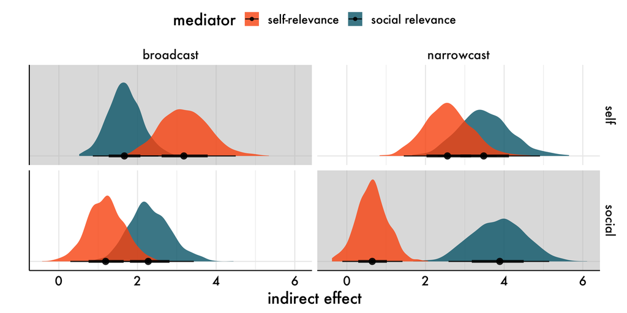

```r
labels = data.frame(model = c("self", "social"),
                    outcome = c("broadcast", "narrowcast"),
                    value = c(1, 1))

create_paths(model_self_broad, "self", "broadcast") %>%
  bind_rows(create_paths(model_self_narrow, "self", "narrowcast")) %>%
  bind_rows(create_paths(model_social_broad, "social", "broadcast")) %>%
  bind_rows(create_paths(model_social_narrow, "social", "narrowcast")) %>%
  select(model, outcome, a1b1_cov_a1b1, a2b2_cov_a2b2) %>%
  gather(path, value, -model, -outcome) %>%
  mutate(path = ifelse(path == "a1b1_cov_a1b1", "self-relevance", "social relevance")) %>%
  ggplot(aes(x = value, y = "", fill = path)) +
  geom_rect(data = labels,
            aes(xmin = -Inf, xmax = Inf, ymin = -Inf, ymax = Inf),
            alpha = .5, fill = "grey") +
  stat_halfeye(alpha = .8) +
  facet_grid(model ~ outcome) +
  scale_y_discrete(expand = c(.1, 0)) +
  scale_fill_manual(values = palette_relevance, name = "mediator") +
  labs(x = "indirect effect", y = "") +
  plot_aes
```

## word count analyses

In these analyses we looked at how depth of processing, operationalized as word count, is related to the outcomes of interest.

### word count by condition

Does word count differ by condition?

#### summarize

```r
n_words = study6_comments %>%
  mutate(study = "study 6",
         item = sprintf("%s_%s", content, article_number),
         SID = sprintf("%s_%s", study, SID)) %>%
  group_by(article_cond, SID, item) %>%
  tidytext::unnest_tokens(word, value) %>%
  summarize(n = n())

words_ratings = n_words %>%
  left_join(., study6, by = c()) %>%
  ungroup() %>%
  mutate(n_c = n - mean(n, na.rm = TRUE))

n_words %>%
  group_by(article_cond) %>%
  summarize(mean = mean(n, na.rm = TRUE),
            sd = sd(n, na.rm = TRUE),
            min = min(n, na.rm = TRUE),
            max = max(n, na.rm = TRUE)) %>%
  kable(digits = 2) %>%
  kableExtra::kable_styling()
```

| article_cond | mean | sd | min | max |
| --- | --- | --- | --- | --- |
| control | 13.53 | 8.21 | 2 | 89 |
| self | 16.62 | 10.69 | 2 | 97 |
| social | 16.58 | 9.99 | 3 | 59 |

#### rsharing

```r
mod_words = lmer(n ~ 1 + article_cond + (1 | SID),
              data = n_words,
              control = lmerControl(optimizer = "bobyqa"))

table_model(mod_words, eff_size = FALSE)
```

| term | b [95% CI] | df | t | p |
| --- | --- | --- | --- | --- |
| control | 13.53 [12.75, 14.31] | 437.17 | 33.98 | < .001 |
| self | 3.08 [2.60, 3.56] | 3725.05 | 12.63 | < .001 |
| social | 3.05 [2.57, 3.54] | 3727.22 | 12.43 | < .001 |

#### self-relevance

```r
mod_words_h1 = lmer(msg_rel_self ~ 1 + n_c + (1 + n_c | SID),
              data = words_ratings,
              control = lmerControl(optimizer = "bobyqa"))

table_model(mod_words_h1, eff_size = FALSE)
```

| term | b [95% CI] | df | t | p |
| --- | --- | --- | --- | --- |
| control | 57.28 [55.09, 59.47] | 389.24 | 51.49 | < .001 |
| word count | 0.50 [0.32, 0.67] | 273.86 | 5.62 | < .001 |

#### social relevance

```r
mod_words_h2 = lmer(msg_rel_social ~ 1 + n_c + (1 + n_c | SID),
              data = words_ratings,
              control = lmerControl(optimizer = "bobyqa"))

table_model(mod_words_h2, eff_size = FALSE)
```

| term | b [95% CI] | df | t | p |
| --- | --- | --- | --- | --- |
| control | 62.75 [60.69, 64.82] | 389.46 | 59.79 | < .001 |
| word count | 0.48 [0.33, 0.63] | 236.60 | 6.45 | < .001 |

### mediation models

Is the relationship between experimental condition (self, social, or control) and relevance (self or social) mediated by word count?

#### self –> self relevance

```r
x_var = "self"
y_var = "msg_rel_self"
model_name = "mediation_self_words_selfrelevance_brm"
data = words_ratings %>%
  filter(group == "self")
model_formula = bf(n_c ~ article_cond + (1 + article_cond |i| SID)) +
  bf(paste0(y_var, " ~ article_cond + n_c + (1 + n_c |i| SID)")) +
  set_rescor(FALSE)

model_self_word = run_brm_model(model_name, model_formula, y_var, data)
get_paths_words(model_self_word, x_var, y_var)
```

| path | Mdn [95% CI] |
| --- | --- |
| a1 | 3.08 [2.30, 3.84] |
| b1 | 0.38 [0.12, 0.63] |
| a1b1 | 1.16 [0.32, 2.08] |
| a1b1_cov_a1b1 | 2.18 [1.00, 3.59] |
| c | 11.59 [9.91, 13.32] |
| c_prime | 10.42 [8.84, 12.13] |

```r
percent_mediated_words(model_self_word, x_var, y_var)
```

percent mediated

| word_count |
| --- |
| 19 |

#### self –> social relevance

```r
x_var = "self"
y_var = "msg_rel_social"
model_name = "mediation_self_words_socialrelevance_brm"
data = words_ratings %>%
  filter(group == "self")
model_formula = bf(n_c ~ article_cond + (1 + article_cond |i| SID)) +
  bf(paste0(y_var, " ~ article_cond + n_c + (1 + n_c |i| SID)")) +
  set_rescor(FALSE)

model_self_word = run_brm_model(model_name, model_formula, y_var, data)
get_paths_words(model_self_word, x_var, y_var)
```

| path | Mdn [95% CI] |
| --- | --- |
| a1 | 3.07 [2.30, 3.81] |
| b1 | 0.34 [0.13, 0.53] |
| a1b1 | 1.02 [0.35, 1.81] |
| a1b1_cov_a1b1 | 1.14 [0.11, 2.21] |
| c | 8.85 [7.34, 10.29] |
| c_prime | 7.82 [6.41, 9.28] |

```r
percent_mediated_words(model_self_word, x_var, y_var)
```

percent mediated

| word_count |
| --- |
| 13 |

#### social –> social relevance

```r
x_var = "social"
y_var = "msg_rel_social"
model_name = "mediation_social_words_socialrelevance_brm"
data = words_ratings %>%
  filter(group == "social")
model_formula = bf(n_c ~ article_cond + (1 + article_cond |i| SID)) +
  bf(paste0(y_var, " ~ article_cond + n_c + (1 + n_c |i| SID)")) +
  set_rescor(FALSE)

model_social_word = run_brm_model(model_name, model_formula, y_var, data)
get_paths_words(model_social_word, x_var, y_var)
```

| path | Mdn [95% CI] |
| --- | --- |
| a1 | 3.05 [2.29, 3.81] |
| b1 | 0.18 [-0.04, 0.42] |
| a1b1 | 0.54 [-0.10, 1.33] |
| a1b1_cov_a1b1 | 1.19 [0.15, 2.26] |
| c | 7.88 [6.50, 9.47] |
| c_prime | 7.35 [5.91, 8.78] |

```r
percent_mediated_words(model_social_word, x_var, y_var)
```

percent mediated

| word_count |
| --- |
| 15 |

#### social –> self relevance

```r
x_var = "social"
y_var = "msg_rel_self"
model_name = "mediation_social_words_selfrelevance_brm"
data = words_ratings %>%
  filter(group == "social")
model_formula = bf(n_c ~ article_cond + (1 + article_cond |i| SID)) +
  bf(paste0(y_var, " ~ article_cond + n_c + (1 + n_c |i| SID)")) +
  set_rescor(FALSE)

model_social_word = run_brm_model(model_name, model_formula, y_var, data)
get_paths_words(model_social_word, x_var, y_var)
```

| path | Mdn [95% CI] |
| --- | --- |
| a1 | 3.05 [2.33, 3.74] |
| b1 | 0.21 [-0.05, 0.48] |
| a1b1 | 0.65 [-0.14, 1.54] |
| a1b1_cov_a1b1 | 0.79 [-0.35, 2.04] |
| c | 4.81 [3.06, 6.41] |
| c_prime | 4.14 [2.46, 5.83] |

```r
percent_mediated_words(model_social_word, x_var, y_var)
```

percent mediated

| word_count |
| --- |
| 16 |